# Hubway

Felipe Clement Santacruz

2019-05-27

# 1 Carga de Datasets

Se realiza la carga de los datasets:

- `trips`: Archivo CSV con viajes de Hubway
- `stations`: Archivo CSV con estaciones de Hubway

## 1.1 Viajes

```r
trips_raw <- read.csv("trips.csv")
str(trips_raw)
```

```
## 'data.frame':    1579025 obs. of  13 variables:
##  $ seq_id    : int  1 2 3 4 5 6 7 8 9 10 ...
##  $ hubway_id : int  8 9 10 11 12 13 14 15 16 17 ...
##  $ status    : Factor w/ 1 level "Closed": 1 1 1 1 1 1 1 1 1 1 ...
##  $ duration  : int  9 220 56 64 12 19 24 7 8 1108 ...
##  $ start_date: Factor w/ 521432 levels "10/1/2011 00:01:00",..: 337342 337343 337344 337345 337346 337347 337348 337349 337350 337351 ...
##  $ strt_statn: int  23 23 23 23 23 23 23 23 23 47 ...
##  $ end_date  : Factor w/ 515102 levels "10/1/2011 00:00:00",..: 333544 333545 333546 333547 333548 333549 333550 333551 333552 333559 ...
##  $ end_statn : int  23 23 23 23 23 23 23 23 23 40 ...
##  $ bike_nr   : Factor w/ 1164 levels "","A07799","A07800",..: 484 569 472 569 569 472 569 569 569 565 ...
##  $ subsc_type: Factor w/ 2 levels "Casual","Registered": 2 2 2 2 2 2 2 2 2 2 ...
##  $ zip_code  : Factor w/ 531 levels "","'00210","'00216",..: 523 233 168 176 522 143 199 199 522 104 ...
##  $ birth_date: int  1976 1966 1943 1981 1983 1951 1971 1971 1983 1994 ...
##  $ gender    : Factor w/ 3 levels "","Female","Male": 3 3 3 2 2 3 2 2 2 3 ...
```

## 1.2 Stations

```r
stations_raw <- read.csv("stations.csv")
str(stations_raw)
```

```
## 'data.frame':    142 obs. of  7 variables:
##  $ id       : int  3 4 5 6 7 8 9 10 11 12 ...
##  $ terminal : Factor w/ 131 levels "A32000","A32001",..: 20 35 26 55 1 2 3 4 5 16 ...
##  $ station  : Factor w/ 137 levels "359 Broadway - Broadway at Fayette Street",..: 38 126 95 28 49 127 2 6 82 107 ...
##  $ municipal: Factor w/ 4 levels "Boston","Brookline",..: 1 1 1 1 1 1 1 1 1 1 ...
##  $ lat      : num  42.3 42.3 42.3 42.4 42.4 ...
##  $ lng      : num  -71.1 -71.1 -71.1 -71.1 -71 ...
##  $ status   : Factor w/ 2 levels "Existing","Removed": 1 1 1 1 1 1 1 1 1 1 ...
```

## 1.3 Crimes

```r
crimes_raw <- read.csv("crimes.csv", sep = ";")
str(crimes_raw)
```

```
## 'data.frame':    327820 obs. of  12 variables:
##  $ INCIDENT_NUMBER    : Factor w/ 290156 levels "142052550","I010370257-00",..: 290156 290155 290154 290153 290152 290151 290150 290149 290148 290147 ...
##  $ OFFENSE_CODE_GROUP : Factor w/ 67 levels "Aggravated Assault",..: 15 53 47 1 2 64 44 65 62 63 ...
##  $ OFFENSE_DESCRIPTION: Factor w/ 244 levels "A&B HANDS, FEET, ETC.  - MED. ATTENTION REQ.",..: 63 187 222 13 5 231 162 232 21 223 ...
##  $ DISTRICT           : Factor w/ 13 levels "","A1","A15",..: 12 9 5 2 4 7 1 5 12 10 ...
##  $ REPORTING_AREA     : int  495 795 329 92 36 351 NA 603 543 621 ...
##  $ DAY_OF_WEEK        : Factor w/ 7 levels "Friday","Monday",..: 7 5 7 7 7 6 7 7 7 7 ...
##  $ HOUR               : int  20 20 19 20 20 20 20 19 19 20 ...
##  $ UCR_PART           : Factor w/ 5 levels "","Other","Part One",..: 5 4 5 3 4 5 4 4 5 4 ...
##  $ STREET             : Factor w/ 4685 levels ""," ALBANY ST ",..: 242 145 1275 730 3410 1317 1 4213 307 1025 ...
##  $ LATITUDE           : num  42.3 42.4 42.3 42.4 42.4 ...
##  $ LONGITUDE          : num  -71.1 -71.1 -71.1 -71.1 -71 ...
##  $ LOCATION           : Factor w/ 18255 levels "(-1.00000000, -1.00000000)",..: 906 14711 7033 15950 17227 5997 9166 11261 606 13936 ...
```

# 2 Limpieza

Se procede a limpiar cada dataset.

## 2.1 Viajes

### 2.1.1 Utilidad de las columnas

Se realiza un resumen basico de las variables.

```r
summary(trips_raw)
```

```
##      seq_id          hubway_id          status           duration
##  Min.   :      1   Min.   :      8   Closed:1579025   Min.   :   -6900
##  1st Qu.: 394757   1st Qu.: 446525                    1st Qu.:     412
##  Median : 789513   Median : 895044                    Median :     660
##  Mean   : 789513   Mean   : 886532                    Mean   :    1200
##  3rd Qu.:1184269   3rd Qu.:1328083                    3rd Qu.:    1082
##  Max.   :1579025   Max.   :1748022                    Max.   :11994458
##
##                start_date        strt_statn
##  7/30/2013 17:18:00 :     25   Min.   :  3.00
##  8/6/2013 17:50:00  :     25   1st Qu.: 27.00
##  9/10/2013 17:04:00 :     25   Median : 48.00
##  10/4/2013 17:06:00 :     24   Mean   : 54.38
##  7/30/2013 17:30:00 :     24   3rd Qu.: 74.00
##  10/17/2013 17:04:00:     23   Max.   :145.00
##  (Other)            :1578879   NA's   :14
##                 end_date         end_statn         bike_nr
##  10/19/2013 16:26:00:     27   Min.   :  3.00   B00490 :   2138
##  9/10/2013 17:43:00 :     26   1st Qu.: 29.00   B00268 :   2124
##  8/13/2013 18:08:00 :     24   Median : 48.00   B00548 :   2112
##  8/5/2013 17:30:00  :     24   Mean   : 54.26   B00559 :   2091
##  10/17/2013 17:24:00:     23   3rd Qu.: 74.00   B00563 :   2080
##  7/12/2013 08:56:00 :     23   Max.   :145.00   B00391 :   2072
##  (Other)            :1578878   NA's   :45       (Other):1566408
##       subsc_type         zip_code        birth_date         gender
##  Casual    : 472611          :472766   Min.   :1932            :472611
##  Registered:1106414   '02118 :121749   1st Qu.:1969      Female:271700
##                       '02139 : 89437   Median :1979      Male  :834714
##                       '02215 : 86758   Mean   :1976
##                       '02116 : 77279   3rd Qu.:1985
##                       '02115 : 57522   Max.   :1995
##                       (Other):673514   NA's   :1228381
```

Se encuentra lo siguiente con respecto a la utilidad de las columnas:

| Variable | Condicion | Accion |
| --- | --- | --- |
| `seq_id`, `hubway_id`, `bike_nr` | Son un id’s de base de datos, no tienen significado y no sirven para unir con otro dataset | Remover del dataset |
| `status` | Es un factor con un solo nivel, no tiene utilidad | Remover del dataset |

```r
columns_to_remove <- c("seq_id", "hubway_id", "bike_nr", "status")

trips_tidy <- trips_raw[, -which(colnames(trips_raw) %in% columns_to_remove)]
str(trips_tidy)
```

```
## 'data.frame':    1579025 obs. of  9 variables:
##  $ duration  : int  9 220 56 64 12 19 24 7 8 1108 ...
##  $ start_date: Factor w/ 521432 levels "10/1/2011 00:01:00",..: 337342 337343 337344 337345 337346 337347 337348 337349 337350 337351 ...
##  $ strt_statn: int  23 23 23 23 23 23 23 23 23 47 ...
##  $ end_date  : Factor w/ 515102 levels "10/1/2011 00:00:00",..: 333544 333545 333546 333547 333548 333549 333550 333551 333552 333559 ...
##  $ end_statn : int  23 23 23 23 23 23 23 23 23 40 ...
##  $ subsc_type: Factor w/ 2 levels "Casual","Registered": 2 2 2 2 2 2 2 2 2 2 ...
##  $ zip_code  : Factor w/ 531 levels "","'00210","'00216",..: 523 233 168 176 522 143 199 199 522 104 ...
##  $ birth_date: int  1976 1966 1943 1981 1983 1951 1971 1971 1983 1994 ...
##  $ gender    : Factor w/ 3 levels "","Female","Male": 3 3 3 2 2 3 2 2 2 3 ...
```

Adicionalmente, puesto a que se busca analizar las edades de los usuarios, la columna `birht_date` sera convertida en `age`.

```r
trips_tidy <- trips_tidy %>% rename(age = birth_date)

# 2014 is the year in which the data was generated
trips_tidy$age <- 2014 - trips_tidy$age
```

### 2.1.2 Tipos de columnas

Las columnas `start_date` y `end_date` deben ser convertidas a un formato de tiempo.

```r
trips_tidy$start_date <- as.POSIXct(trips_tidy$start_date, tz = "EST", format = "%m/%d/%Y %H:%M:%S")
trips_tidy$end_date <- as.POSIXct(trips_tidy$end_date, tz = "EST", format = "%m/%d/%Y %H:%M:%S")

# Verificamos que todas las fechas hayan sido transformadas exitosamente
which(is.na(trips_tidy$start_date))
```

```
## integer(0)
```

```r
which(is.na(trips_tidy$end_date))
```

```
## integer(0)
```

```r
str(trips_tidy)
```

```
## 'data.frame':    1579025 obs. of  9 variables:
##  $ duration  : int  9 220 56 64 12 19 24 7 8 1108 ...
##  $ start_date: POSIXct, format: "2011-07-28 10:12:00" "2011-07-28 10:21:00" ...
##  $ strt_statn: int  23 23 23 23 23 23 23 23 23 47 ...
##  $ end_date  : POSIXct, format: "2011-07-28 10:12:00" "2011-07-28 10:25:00" ...
##  $ end_statn : int  23 23 23 23 23 23 23 23 23 40 ...
##  $ subsc_type: Factor w/ 2 levels "Casual","Registered": 2 2 2 2 2 2 2 2 2 2 ...
##  $ zip_code  : Factor w/ 531 levels "","'00210","'00216",..: 523 233 168 176 522 143 199 199 522 104 ...
##  $ age       : num  38 48 71 33 31 63 43 43 31 20 ...
##  $ gender    : Factor w/ 3 levels "","Female","Male": 3 3 3 2 2 3 2 2 2 3 ...
```

### 2.1.3 Limpieza de columnas

#### 2.1.3.1 Duration

```r
summary(trips_tidy$duration)
```

```
##     Min.  1st Qu.   Median     Mean  3rd Qu.     Max.
##    -6900      412      660     1200     1082 11994458
```

Esta columna parece tener duraciones negativas y muy altas, observaremos la distribución.

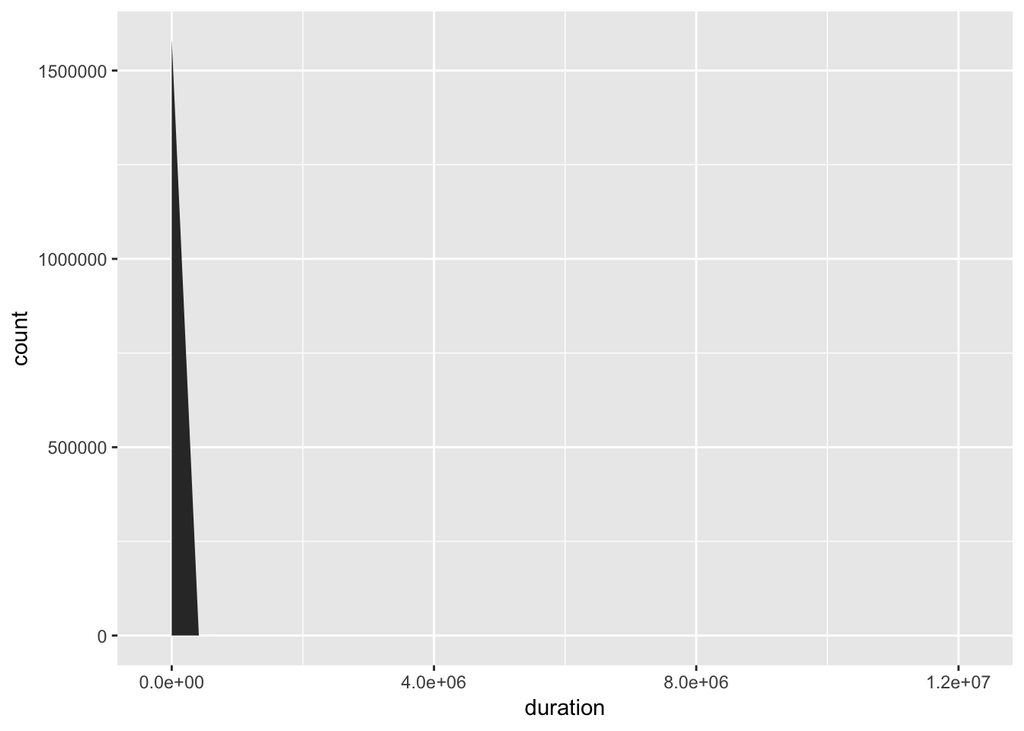

```r
ggplot(trips_tidy, aes(duration)) + geom_area(stat = "bin")
```

```r
range_duration <- range(trips_tidy$duration)
range_duration
```

```
## [1]    -6900 11994458
```

```r
day_seconds <- 60 * 60 * 24

abs(range_duration[1] - range_duration[2]) / day_seconds
```

```
## [1] 138.9046
```

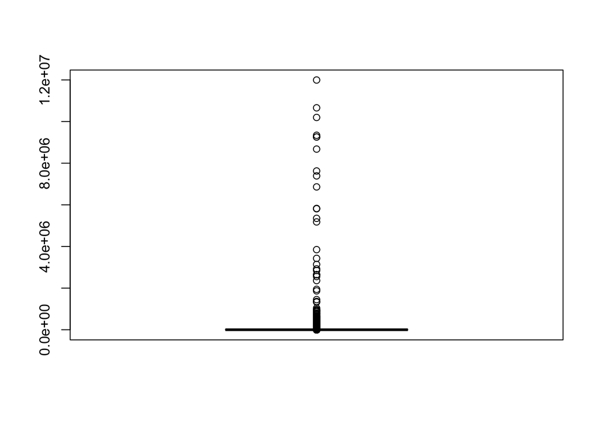

```r
boxplot_duration <- boxplot(trips_tidy$duration)
```

```r
duration_outliers <- boxplot_duration$out
number_of_outliers <- length(which(trips_tidy$duration %in% duration_outliers))

(number_of_outliers * 100) / length(trips_tidy$duration)
```

```
## [1] 6.613828
```

Visualizando la data sin los outliers (los picos en la distribución representan duraciones multiplo de 60, que significa los minutos que contabiliza la aplicacion):

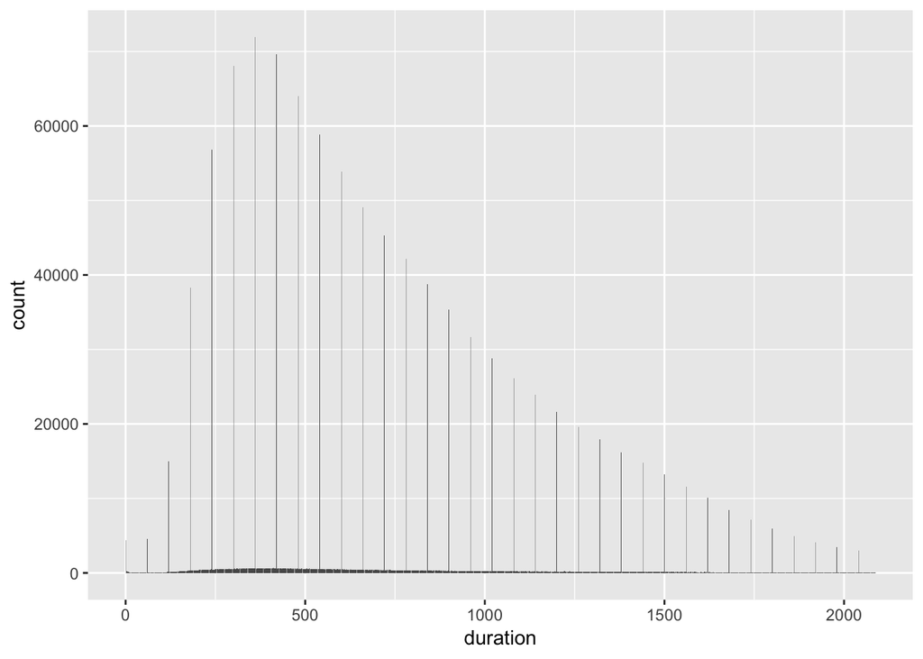

```r
trips_duration_no_outliers <- trips_tidy[-which(trips_tidy$duration %in% duration_outliers), ]

ggplot(trips_duration_no_outliers, aes(duration)) + geom_bar()
```

Se remueven los registros con valores de `duration` negativos; los outliers positivos no se remueven, pues bajo la suscripcion anual, parece que un usuario puede rentar una bicicleta por 365 maximo.

```r
trips <- trips_tidy[-which(trips_tidy$duration < 0), ]
str(trips)
```

```
## 'data.frame':    1578976 obs. of  9 variables:
##  $ duration  : int  9 220 56 64 12 19 24 7 8 1108 ...
##  $ start_date: POSIXct, format: "2011-07-28 10:12:00" "2011-07-28 10:21:00" ...
##  $ strt_statn: int  23 23 23 23 23 23 23 23 23 47 ...
##  $ end_date  : POSIXct, format: "2011-07-28 10:12:00" "2011-07-28 10:25:00" ...
##  $ end_statn : int  23 23 23 23 23 23 23 23 23 40 ...
##  $ subsc_type: Factor w/ 2 levels "Casual","Registered": 2 2 2 2 2 2 2 2 2 2 ...
##  $ zip_code  : Factor w/ 531 levels "","'00210","'00216",..: 523 233 168 176 522 143 199 199 522 104 ...
##  $ age       : num  38 48 71 33 31 63 43 43 31 20 ...
##  $ gender    : Factor w/ 3 levels "","Female","Male": 3 3 3 2 2 3 2 2 2 3 ...
```

#### 2.1.3.2 Estacion de inicio

Esta columna no requiere limpieza.

```r
summary(trips$strt_statn)
```

```
##    Min. 1st Qu.  Median    Mean 3rd Qu.    Max.    NA's
##    3.00   27.00   48.00   54.38   74.00  145.00      14
```

#### 2.1.3.3 Estacion final

Esta columna no requiere limpieza.

```r
summary(trips$end_statn)
```

```
##    Min. 1st Qu.  Median    Mean 3rd Qu.    Max.    NA's
##    3.00   29.00   48.00   54.26   74.00  145.00      45
```

#### 2.1.3.4 Tipo de usuario

Esta columna no requiere limpieza.

```r
summary(trips$subsc_type)
```

```
##     Casual Registered
##     472577    1106399
```

#### 2.1.3.5 Codigo postal

Esta columna no requiere limpieza.

```r
summary(trips$zip_code)
```

```
##          '02118  '02139  '02215  '02116  '02115  '02138  '02114  '02143
##  472732  121749   89436   86757   77277   57521   39488   38307   36591
##  '02113  '02134  '02446  '02109  '02129  '02144  '02111  '02108  '02110
##   34376   28715   28159   22873   22640   15889   15074   14901   13857
##  '02141  '02127  '02135  '02120  '02445  '02130  '02210  '02128  '02142
##   13793   13363   12882   12406   11134   10853   10020    8913    8780
##  '02163  '02119  '02140  '02043  '02155  '01915  '01890  '02199  '02125
##    8386    8323    8249    8021    6634    6404    6036    4898    4782
##  '02478  '01867  '02066  '02145  '02025  '01944  '01760  '01930  '02171
##    4365    4037    3924    3881    3638    3363    3347    3303    3198
##  '01742  '02026  '01907  '02474  '01720  '02148  '01970  '02124  '02131
##    3171    3167    3081    2984    2935    2901    2824    2778    2640
##  '02176  '01982  '01880  '02045  '02492  '01945  '02021  '01938  '02067
##    2522    2479    2378    2292    2144    2102    1996    1914    1881
##  '02453  '02465  '02468  '01810  '02169  '02050  '02332  '02467  '01460
##    1835    1745    1734    1723    1699    1580    1578    1557    1527
##  '02472  '02151  '01773  '02481  '02132  '02476  '02458  '02482  '02461
##    1517    1482    1479    1473    1427    1365    1336    1273    1253
##  '02360  '02420  '01923  '01984  '02048  '01902  '02186  '02451  '02205
##    1238    1225    1210    1174    1122    1117    1113    1106    1104
##  '02056  '02459  '01876  '01966  '01950  '02122  '01826  '02038  '01845
##    1101    1096    1063    1035    1027    1011     989     978     977
## (Other)
##   72243
```

#### 2.1.3.6 Dia de inicio de renta

Podemos observar que esta columna no parecen presentar valores fuera de rango.

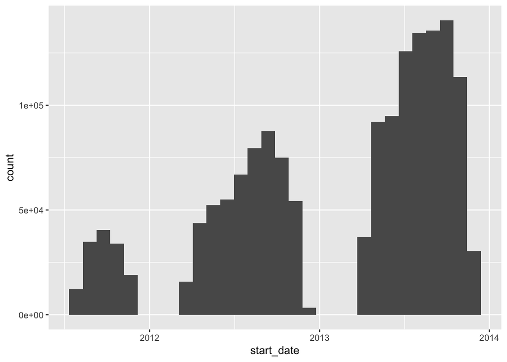

```r
ggplot(trips, aes(start_date, ..count..)) + geom_histogram()
```

#### 2.1.3.7 Dia de fin de renta

Podemos observar que esta columna no parecen presentar valores fuera de rango.

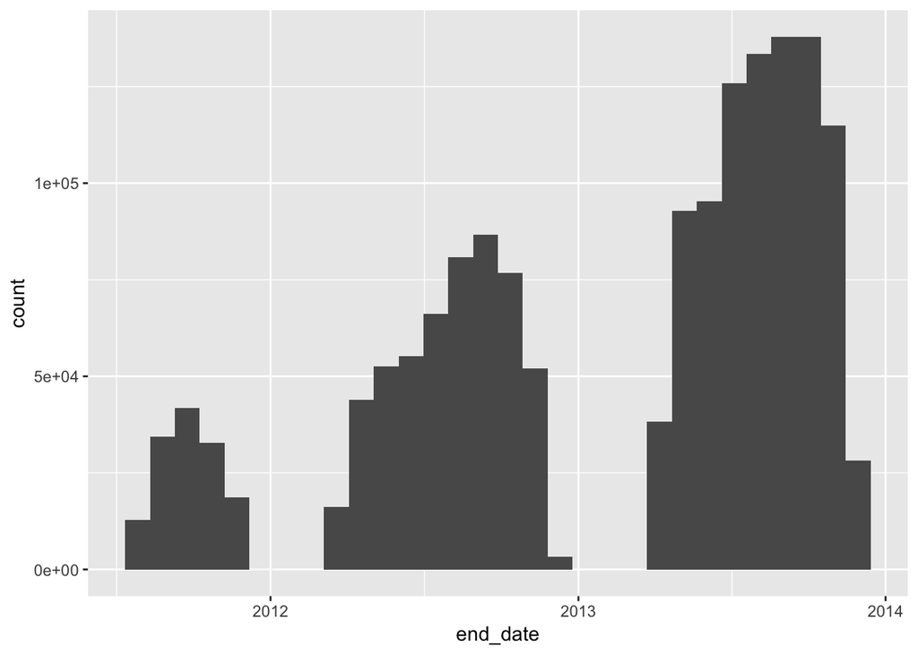

```r
ggplot(trips, aes(end_date, ..count..)) + geom_histogram()
```

#### 2.1.3.8 Edad

Esta columna no requiere limpieza.

```r
summary(trips$age)
```

```
##    Min. 1st Qu.  Median    Mean 3rd Qu.    Max.    NA's
##    19.0    29.0    35.0    37.7    45.0    82.0 1228332
```

#### 2.1.3.9 Genero

Esta columna no requiere limpieza.

```r
summary(trips$gender)
```

```
##        Female   Male
## 472577 271697 834702
```

## 2.2 Estaciones

### 2.2.1 Utilidad de las columnas

Se realiza un resumen basico de las variables.

```r
summary(stations_raw)
```

```
##        id            terminal
##  Min.   :  3.00   B32008 :  2
##  1st Qu.: 39.25   B32017 :  2
##  Median : 74.50   C32002 :  2
##  Mean   : 74.32   C32008 :  2
##  3rd Qu.:109.75   C32012 :  2
##  Max.   :145.00   D32001 :  2
##                   (Other):130
##                                            station         municipal
##  Andrew Station - Dorchester Ave at Humboldt Pl:  2   Boston    :97
##  Boylston at Fairfield                         :  2   Brookline : 5
##  Charles Circle - Charles St. at Cambridge St. :  2   Cambridge :28
##  Dudley Square                                 :  2   Somerville:12
##  Mayor Thomas M. Menino - Government Center    :  2
##  359 Broadway - Broadway at Fayette Street     :  1
##  (Other)                                       :131
##       lat             lng              status
##  Min.   :42.31   Min.   :-71.15   Existing:130
##  1st Qu.:42.34   1st Qu.:-71.11   Removed : 12
##  Median :42.35   Median :-71.09
##  Mean   :42.35   Mean   :-71.09
##  3rd Qu.:42.37   3rd Qu.:-71.07
##  Max.   :42.40   Max.   :-71.04
##
```

Las columna `terminal` es un identificador que no tiene significado y tampoco sirve para hacer un join con otros datos, se removera.

```r
stations_columns_to_remove <- c("terminal")

stations <- stations_raw[, -which(colnames(stations_raw) %in% stations_columns_to_remove)]
str(stations)
```

```
## 'data.frame':    142 obs. of  6 variables:
##  $ id       : int  3 4 5 6 7 8 9 10 11 12 ...
##  $ station  : Factor w/ 137 levels "359 Broadway - Broadway at Fayette Street",..: 38 126 95 28 49 127 2 6 82 107 ...
##  $ municipal: Factor w/ 4 levels "Boston","Brookline",..: 1 1 1 1 1 1 1 1 1 1 ...
##  $ lat      : num  42.3 42.3 42.3 42.4 42.4 ...
##  $ lng      : num  -71.1 -71.1 -71.1 -71.1 -71 ...
##  $ status   : Factor w/ 2 levels "Existing","Removed": 1 1 1 1 1 1 1 1 1 1 ...
```

# 3 Preguntas de complejidad 1

¿Quién ha utilizado más el servicio de bicicletas?

Para responder las siguientes preguntas se prepara un dataset con el join de los viajes y estaciones.

```r
start_stations <- stations %>% setNames(paste0("start_station_", names(.)))
end_stations <- stations %>% setNames(paste0("end_station_", names(.)))

trips_stations <- trips %>%
  filter(!is.na(strt_statn) & !is.na(end_statn)) %>%
  left_join(start_stations, by = c("strt_statn" = "start_station_id"), copy = TRUE) %>%
  left_join(end_stations, by = c("end_statn" = "end_station_id"), copy = TRUE) %>%
  select(-c(strt_statn, end_statn))

str(trips_stations)
```

```
## 'data.frame':    1578924 obs. of  17 variables:
##  $ duration               : int  9 220 56 64 12 19 24 7 8 1108 ...
##  $ start_date             : POSIXct, format: "2011-07-28 10:12:00" "2011-07-28 10:21:00" ...
##  $ end_date               : POSIXct, format: "2011-07-28 10:12:00" "2011-07-28 10:25:00" ...
##  $ subsc_type             : Factor w/ 2 levels "Casual","Registered": 2 2 2 2 2 2 2 2 2 2 ...
##  $ zip_code               : Factor w/ 531 levels "","'00210","'00216",..: 523 233 168 176 522 143 199 199 522 104 ...
##  $ age                    : num  38 48 71 33 31 63 43 43 31 20 ...
##  $ gender                 : Factor w/ 3 levels "","Female","Male": 3 3 3 2 2 3 2 2 2 3 ...
##  $ start_station_station  : Factor w/ 137 levels "359 Broadway - Broadway at Fayette Street",..: 86 86 86 86 86 86 86 86 86 43 ...
##  $ start_station_municipal: Factor w/ 4 levels "Boston","Brookline",..: 1 1 1 1 1 1 1 1 1 1 ...
##  $ start_station_lat      : num  42.4 42.4 42.4 42.4 42.4 ...
##  $ start_station_lng      : num  -71.1 -71.1 -71.1 -71.1 -71.1 ...
##  $ start_station_status   : Factor w/ 2 levels "Existing","Removed": 2 2 2 2 2 2 2 2 2 1 ...
##  $ end_station_station    : Factor w/ 137 levels "359 Broadway - Broadway at Fayette Street",..: 86 86 86 86 86 86 86 86 86 81 ...
##  $ end_station_municipal  : Factor w/ 4 levels "Boston","Brookline",..: 1 1 1 1 1 1 1 1 1 1 ...
##  $ end_station_lat        : num  42.4 42.4 42.4 42.4 42.4 ...
##  $ end_station_lng        : num  -71.1 -71.1 -71.1 -71.1 -71.1 ...
##  $ end_station_status     : Factor w/ 2 levels "Existing","Removed": 2 2 2 2 2 2 2 2 2 1 ...
```

## 3.1 ¿Mujeres o hombres?

Los hombres utilizan mas el servicio. Aun considerando que el 29.92% de los generos son missing values (`""`), asumiendo que todos estos fuesen mujeres, igualmente no sobrepasaria la cantidad de hombres.

```r
trips_na_gender <- trips[which(trips$gender == ""), ]
trips_female <- trips[which(trips$gender == "Female"), ]
trips_male <- trips[which(trips$gender == "Male"), ]

nrow(trips_male) > nrow(trips_female) + nrow(trips_na_gender)
```

```
## [1] TRUE
```

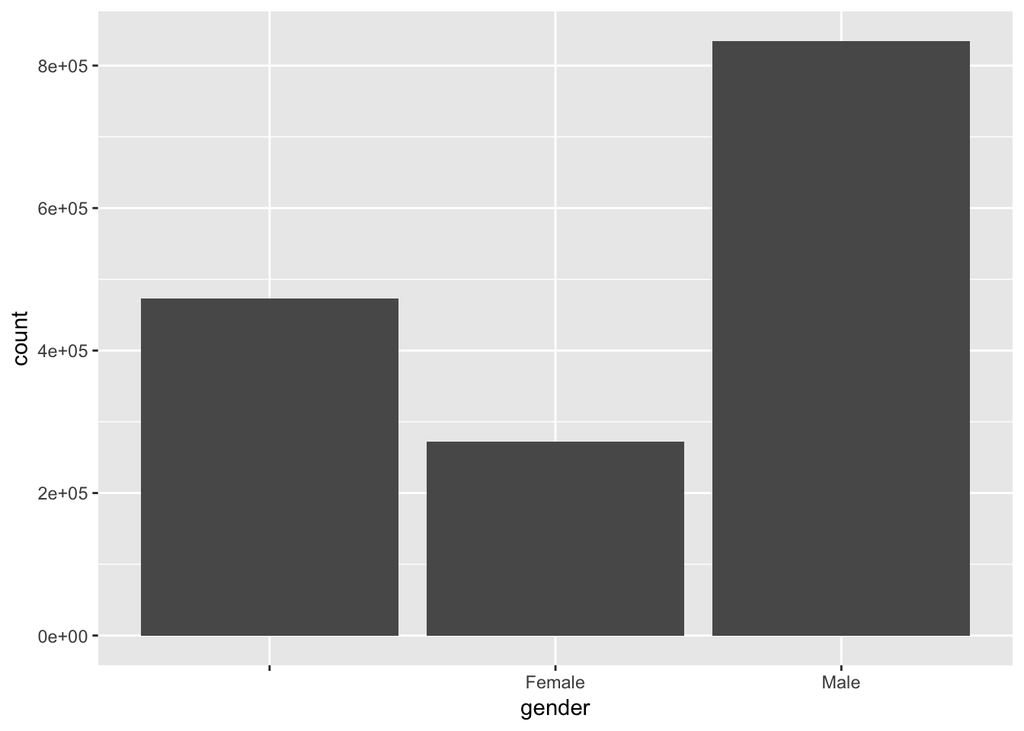

```r
ggplot(trips, aes(gender, ..count..)) + geom_bar()
```

## 3.2 ¿Personas mayores o jóvenes?

El 77.79% de los datos de edad son missing value, por lo tanto no es posible extraer una conclusion final sobre quien usa mas la plataforma.

```r
trips_na_age <- trips[which(is.na(trips$age)), ]

(nrow(trips_na_age) * 100) / nrow(trips)
```

```
## [1] 77.79295
```

Sin embargo, considerando los valores no `NA` podemos observar que la mediana de las edades es 35 años, lo cual indica que el 50% de los usuarios con edad reportada son relativamente jovenes, centrandose alrededor de los 31 años (moda)

```r
median(trips$age, na.rm = TRUE)
```

```
## [1] 35
```

```r
get_mode <- function(var) {
  uniqv <- unique(var)
  uniqv[which.max(tabulate(match(var, uniqv)))]
}

get_mode(trips$age[-which(is.na(trips$age))])
```

```
## [1] 31
```

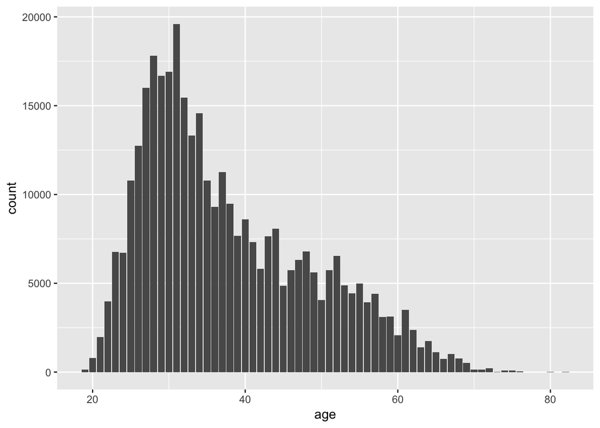

```r
ggplot(trips, aes(age, ..count..)) + geom_bar()
```

## 3.3 ¿Suscritos o solo usuarios que han utilizado el servicio una sola vez?

El tipo de usuario mas frecuente es el registrado.

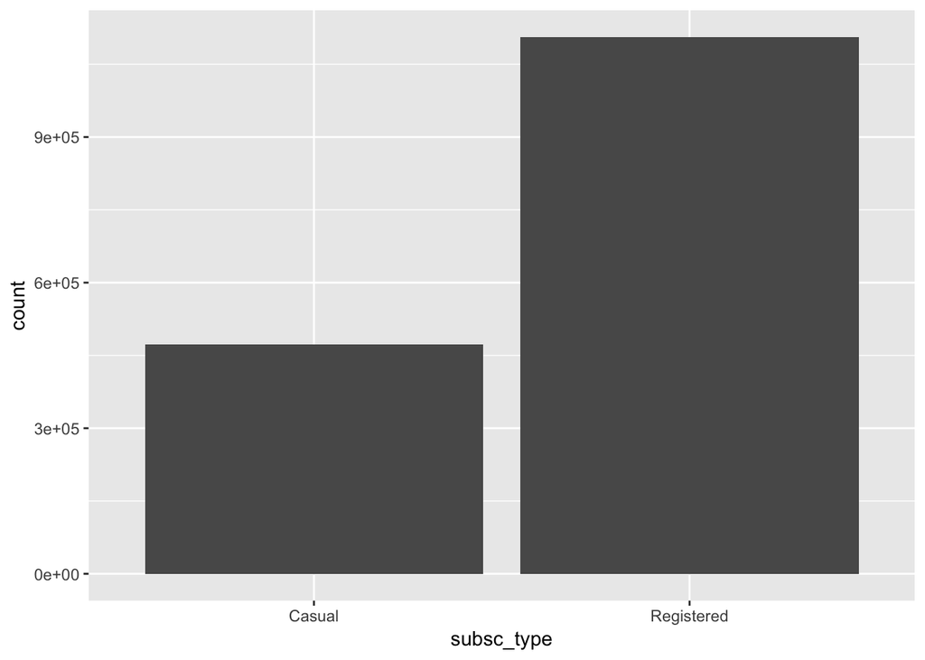

```r
ggplot(trips, aes(subsc_type, ..count..)) + geom_bar()
```

## 3.4 ¿Más en Boston que en Cambridge?

Se han solicitado mas viajes en Boston.

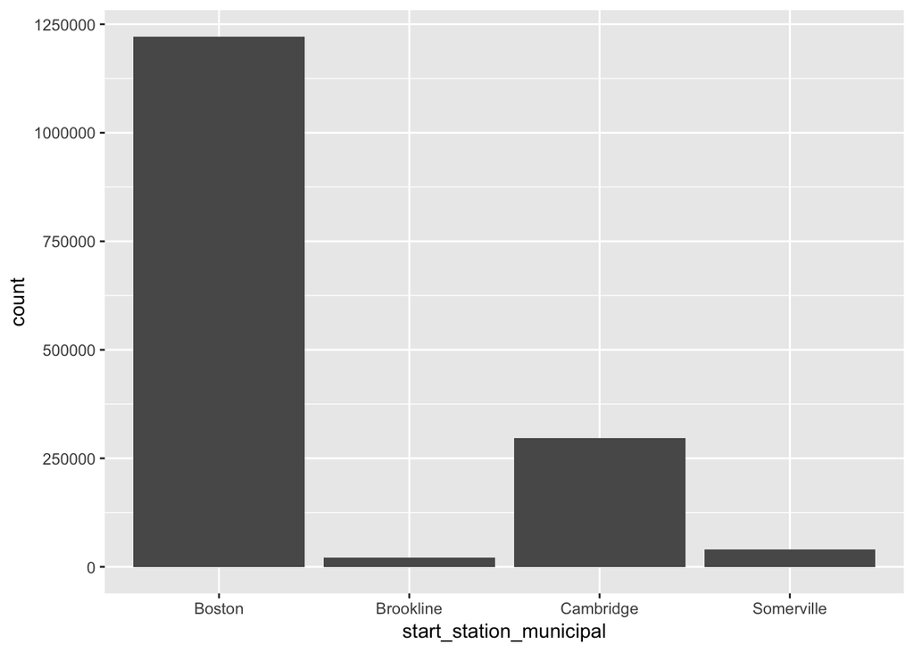

```r
ggplot(trips_stations, aes(start_station_municipal, ..count..)) + geom_bar()
```

## 3.5 ¿Cuáles son las tres estaciones donde han llegado más viajes en estas bicicletas?

```r
top_end_stations <- trips_stations %>%
  group_by(end_station_station) %>%
  summarise(number_of_trips = n()) %>%
  arrange(desc(number_of_trips)) %>%
  top_n(3)
top_end_stations
```

```
## # A tibble: 3 x 2
##   end_station_station                           number_of_trips
##   <fct>                                                   <int>
## 1 South Station - 700 Atlantic Ave.                       56278
## 2 Boston Public Library - 700 Boylston St.                43387
## 3 Charles Circle - Charles St. at Cambridge St.           35357
```

## 3.6 ¿Cuáles son las cinco estaciones desde donde han salido la mayor cantidad de viajes en estas bicicletas?

```r
top_start_stations <- trips_stations %>%
  group_by(start_station_station) %>%
  summarise(number_of_trips = n()) %>%
  arrange(desc(number_of_trips)) %>%
  top_n(5)
top_start_stations
```

```
## # A tibble: 5 x 2
##   start_station_station                         number_of_trips
##   <fct>                                                   <int>
## 1 South Station - 700 Atlantic Ave.                       56440
## 2 Boston Public Library - 700 Boylston St.                42568
## 3 Charles Circle - Charles St. at Cambridge St.           36201
## 4 Beacon St / Mass Ave                                    35438
## 5 MIT at Mass Ave / Amherst St                            33685
```

## 3.7 ¿Cuáles son los cinco recorridos que tuvieron la mayor duración (de mayor a menor)?

Se seleccionan con la duracion en dias.

```r
top_durations <- trips_stations %>%
  select(start_station_station, end_station_station, duration) %>%
  mutate(duration = duration / day_seconds) %>%
  arrange(desc(duration)) %>%
  top_n(5)
top_durations
```

```
##                              start_station_station
## 1                          Christian Science Plaza
## 2            Faneuil Hall - Union St. at North St.
## 3 HMS / HSPH - Ave. Louis Pasteur at Longwood Ave.
## 4                               Post Office Square
## 5                South Station - 700 Atlantic Ave.
##                end_station_station  duration
## 1                         Fan Pier 138.82475
## 2               Congress / Sleeper 107.14419
## 3 Dorchester Ave. at Gillette Park 100.43051
## 4       Rowes Wharf - Atlantic Ave  67.25903
## 5          TD Garden - Legends Way  61.93383
```

## 3.8 ¿Cuáles son los cinco recorridos que tuvieron la menor duración (de menor a mayor)?

Existen recorridos con duraciones en 0 segundos, donde la estacion de inicio y fin son iguales. Esto puede indicar que se trataba de alguna prueba o mal funcionamiento de la plataforma.

```r
bottom_durations <- trips_stations %>%
  select(start_station_station, end_station_station, duration) %>%
  arrange(duration)

head(bottom_durations)
```

```
##                   start_station_station
## 1 Faneuil Hall - Union St. at North St.
## 2               TD Garden - Legends Way
## 3           Lewis Wharf - Atlantic Ave.
## 4               TD Garden - Legends Way
## 5               TD Garden - Legends Way
## 6               TD Garden - Legends Way
##                     end_station_station duration
## 1 Faneuil Hall - Union St. at North St.        0
## 2               TD Garden - Legends Way        0
## 3           Lewis Wharf - Atlantic Ave.        0
## 4               TD Garden - Legends Way        0
## 5               TD Garden - Legends Way        0
## 6               TD Garden - Legends Way        0
```

Sin considerar los viajes en 0 segundos:

```r
bottom_durations <- trips_stations %>%
  select(start_station_station, end_station_station, duration) %>%
  filter(duration > 0) %>%
  arrange(duration)

head(bottom_durations)
```

```
##                      start_station_station
## 1        South Station - 700 Atlantic Ave.
## 2                            Seaport Hotel
## 3                    Summer St. / Arch St.
## 4 Boston Public Library - 700 Boylston St.
## 5        South Station - 700 Atlantic Ave.
## 6 Boston Public Library - 700 Boylston St.
##                        end_station_station duration
## 1        South Station - 700 Atlantic Ave.        1
## 2                            Seaport Hotel        1
## 3                    Summer St. / Arch St.        1
## 4 Boston Public Library - 700 Boylston St.        1
## 5        South Station - 700 Atlantic Ave.        1
## 6 Boston Public Library - 700 Boylston St.        1
```

# 4 Preguntas de complejidad 2

## 4.1 ¿Más durante el fin de semana que durante los días de semana?

Se realizan mas viajes entre semana.

```r
get_weekend <- function(date_posixct) {
  wd <- wday(date_posixct)

  is_weekend <- wd %in% c(1, 7)

  label <- ifelse(is_weekend, "Weekend", "Weekday")

  return(as.factor(label))
}

trips_by_weekend <- trips %>%
  mutate(is_weekend = get_weekend(start_date)) %>%
  select(is_weekend) %>%
  group_by(is_weekend) %>%
  summarise(number_of_trips = n())

trips_by_weekend
```

```
## # A tibble: 2 x 2
##   is_weekend number_of_trips
##   <fct>                <int>
## 1 Weekday            1167210
## 2 Weekend             411766
```

## 4.2 ¿Más durante las horas pico?

Se solicitan mas viajes durante horas pico.

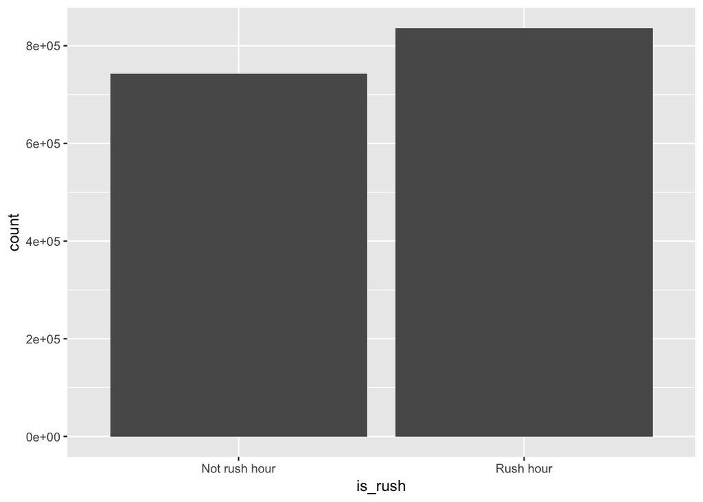

```r
get_rush <- function(date_posixct) {
  h <- hour(date_posixct)

  is_rush <- h %in% c(6:9, 16:19)

  label <- ifelse(is_rush, "Rush hour", "Not rush hour")

  return(as.factor(label))
}

trips_by_rush <- trips %>%
  mutate(is_rush = get_rush(start_date))

ggplot(trips_by_rush, aes(is_rush, ..count..)) + geom_bar()
```

## 4.3 ¿Más durante la temporada de verano que la de otoño?

Se utiliza mas durante otoño.

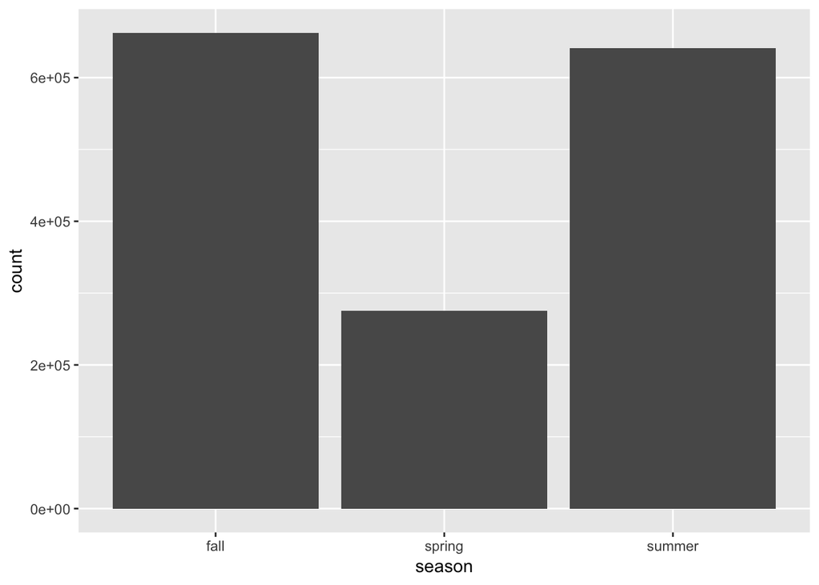

```r
# based on northern meteorooigical seasons
get_season <- function(dt) {
  m <- month(dt)

  label <- NA

  if (m %in% c(3:5)) {
    label <- "spring"
  } else if (m %in% c(6:8)) {
    label <- "summer"
  } else if (m %in% c(9:11)) {
    label <- "fall"
  } else {
    label <- "winter"
  }

  return(label)
}

trips_by_season <- trips
trips_by_season$season <- as.factor(sapply(trips_by_season$start_date, get_season))

ggplot(trips_by_season, aes(season, ..count..)) + geom_bar()
```

## 4.4 ¿Cuáles son las horas de mayor demanda de bicicletas?

Las horas de mayor demanda son a las 8:00 AM y 5:00 PM.

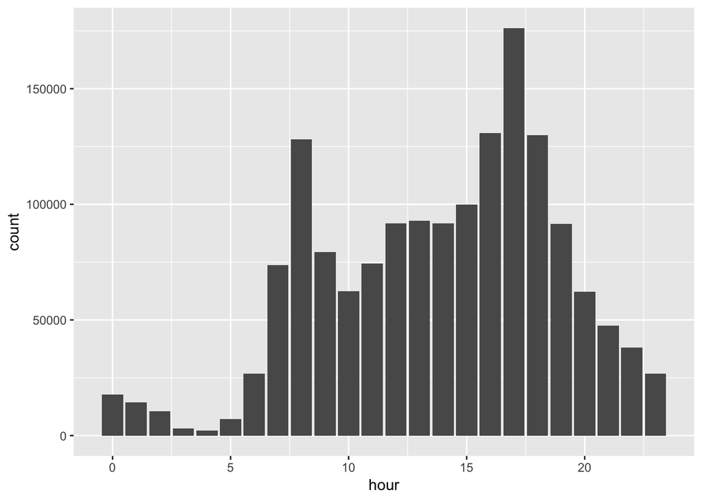

```r
trips_by_hour <- trips %>%
  select(start_date) %>%
  mutate(hour = hour(start_date))

ggplot(trips_by_hour, aes(hour, ..count..)) + geom_bar()
```

# 5 Preguntas de complejidad 3

## 5.1 ¿Cuales son los crímenes más reportados?

Los crimenes mas reportados son accidentes de transito, hurto y asistencia medica.

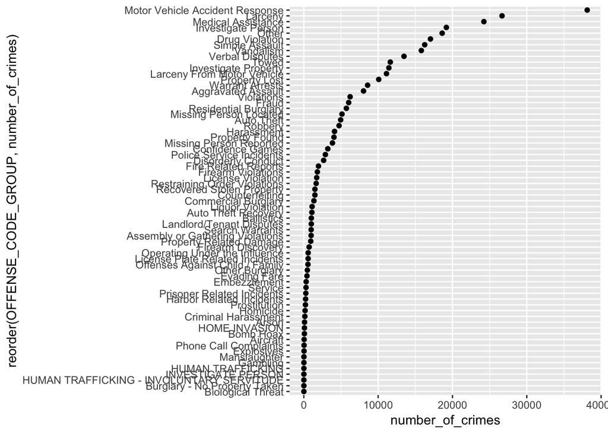

```r
crimes_by_group <- crimes_raw %>%
  group_by(OFFENSE_CODE_GROUP) %>%
  summarise(number_of_crimes = n())

ggplot(crimes_by_group) +
  geom_point(aes(x = reorder(OFFENSE_CODE_GROUP, number_of_crimes), y = number_of_crimes)) +
  coord_flip()
```

## 5.2 ¿Cuáles son los tres barrios más seguros y los tres barrios menos seguros de Boston?

Se visualiza en cuales barrios de Boston se reportan mas crimenes.

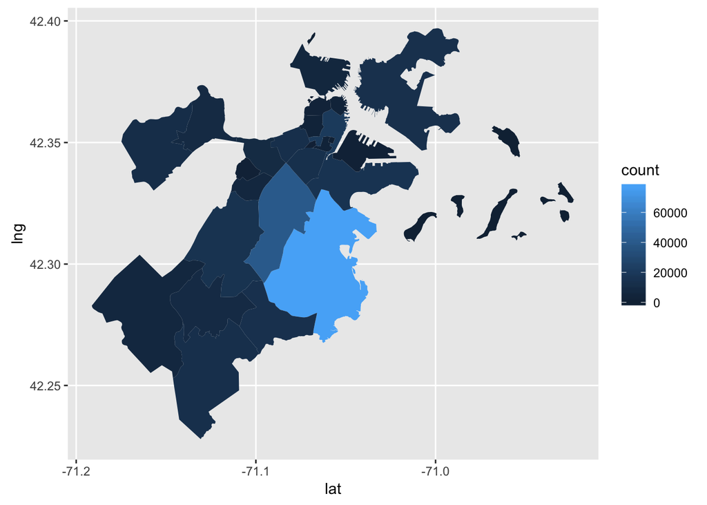

```r
boston_neighborhoods <- read.csv("neighborhoods.csv")

crimes_no_coord_na <- crimes_raw[which(!is.na(crimes_raw$LATITUDE) & !is.na(crimes_raw$LATITUDE)), ]

getCount <- function(lng, lat) {
  count <- point.in.polygon(crimes_no_coord_na$LATITUDE, crimes_no_coord_na$LONGITUDE, lng, lat)

  return(sum(count))
}

grouped_neighborhoods <- boston_neighborhoods %>%
  group_by(neighborhood) %>%
  summarise(count = getCount(lng, lat))

boston_neighborhoods_crimes <- boston_neighborhoods %>%
  left_join(grouped_neighborhoods, by = c("neighborhood" = "neighborhood"), copy = TRUE)

ggplot() +
  geom_polygon(data = boston_neighborhoods_crimes, aes(x = lat, y = lng, group = neighborhood, fill = count)) +
  coord_map()
```

En orden descendente, los barrios con mas crimenes reportados son:

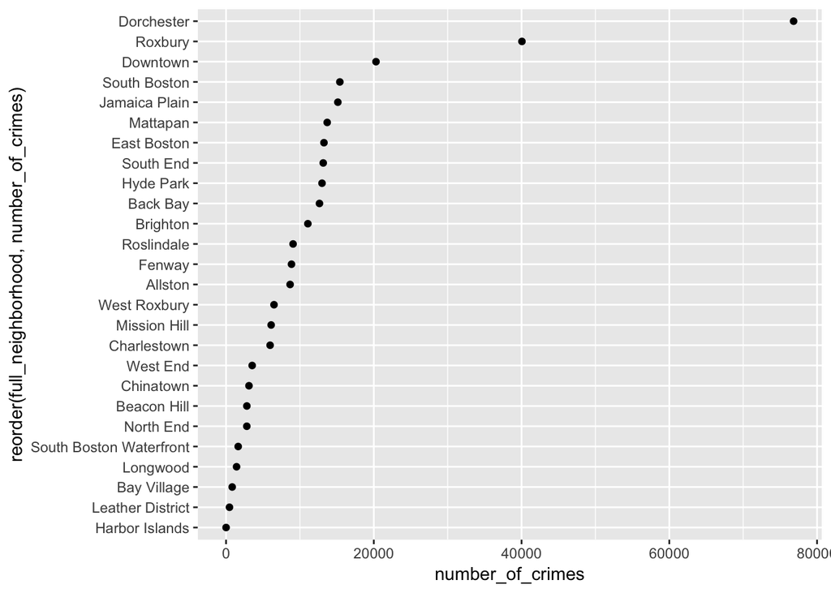

```r
extract_neighborhood <- function(name) {
  ex <- str_extract(name, "[^_\\d]+")

  return(ex)
}

crimes_by_neighborhood <- boston_neighborhoods_crimes %>%
  group_by(neighborhood) %>%
  summarise(number_of_crimes = unique(count)) %>%
  mutate(full_neighborhood = extract_neighborhood(neighborhood)) %>%
  group_by(full_neighborhood) %>%
  summarise(number_of_crimes = sum(number_of_crimes)) %>%
  arrange(desc(number_of_crimes))

ggplot(crimes_by_neighborhood, aes(x = reorder(full_neighborhood, number_of_crimes), y = number_of_crimes)) +
  geom_point() +
  coord_flip()
```